# Kirill Burin - 923357830

# Analysis of Multiple Variables together:

Motivation for choosing separation score is the fact that apart from describing the variables, it will also serve the purpose of knowing which variables have to be selected for predicting the species. Separation score is defined by the amount of uncertainty that is reduced regarding the species due to the variable or the combination of variables used. In simpler terms, it is the reduction of uncertainty in identifying the species based on the variable. The higher the separation score, the higher the amount of uncertainty that has been eliminated. Although there could be variations in the separability among species by different variables, the main purpose remains the same, which is to minimize the uncertainty among the species. Therefore, separation score gives an indication of the strength of a particular variable or combination of variables.

We use combinations of variables, compute the separation score for each one, and then choose the best combination for prediction. In this way, we can identify which combination removes the most entropy.

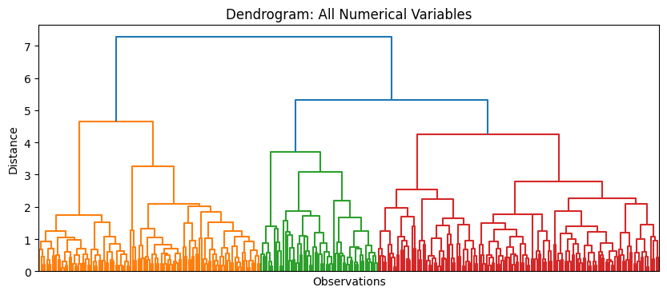

```
Contigency Table:
```

| col_0 species | 1 | 2 | 3 | 4 | 5 | 6 | 7 | 8 | 9 |
| --- | --- | --- | --- | --- | --- | --- | --- | --- | --- |
| Adelie | 0 | 0 | 0 | 0 | 1 | 0 | 53 | 40 | 52 |
| Chinstrap | 0 | 0 | 0 | 12 | 26 | 24 | 1 | 0 | 5 |
| Gentoo | 49 | 4 | 66 | 0 | 0 | 0 | 0 | 0 | 0 |

```python
features = ["bill_length_mm", "bill_depth_mm", "flipper_length_mm", "body_mass_g"]
X_scaled = StandardScaler().fit_transform(df[features])

# Hierarchical clustering
Z = linkage(X_scaled, method="complete", metric="euclidean")

plt.figure(figsize=(10, 4))
dendrogram(Z, no_labels=True)
plt.title("Dendrogram: All Numerical Variables")
plt.xlabel("Observations")
plt.ylabel("Distance")
plt.show()


labels = fcluster(Z, t=2.7, criterion="distance")

# Separation table
h_all4 = pd.crosstab(df["species"], labels)
print("Contigency Table:")
h_all4
```

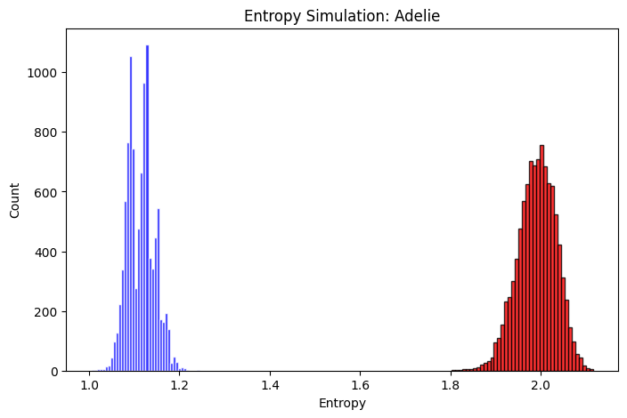

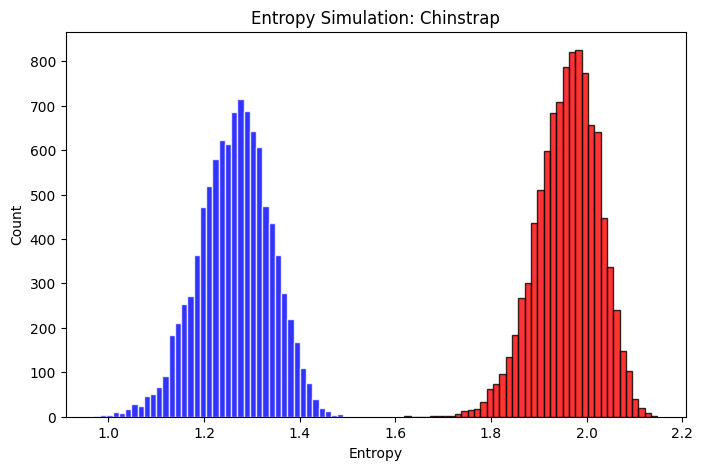

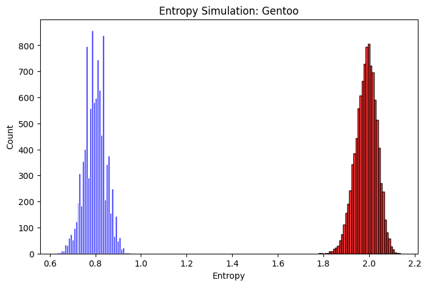

```python
p_null = (h_all4.sum(axis=0) / h_all4.values.sum()).to_numpy()

for sp in h_all4.index:
    row = h_all4.loc[sp].to_numpy()
    n_sp = int(row.sum())
    p_sp = row / n_sp

    ent_null = sim_entropy(n_sp, p_null)
    ent_sp = sim_entropy(n_sp, p_sp)

    plt.figure(figsize=(8,5))
    plt.hist(ent_null, bins=40, edgecolor="black", alpha=0.8, color="red")
    plt.hist(ent_sp, bins=40, edgecolor="white", alpha=0.8, color="blue")
    plt.xlabel("Entropy")
    plt.ylabel("Count")
    plt.title(f"Entropy Simulation: {sp}")
    plt.show()
```

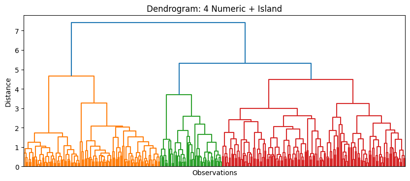

| col_0 species | 1 | 2 | 3 | 4 | 5 | 6 | 7 | 8 | 9 |
| --- | --- | --- | --- | --- | --- | --- | --- | --- | --- |
| Adelie | 0 | 0 | 0 | 0 | 0 | 39 | 47 | 21 | 39 |
| Chinstrap | 0 | 0 | 0 | 12 | 42 | 0 | 5 | 0 | 9 |
| Gentoo | 49 | 4 | 66 | 0 | 0 | 0 | 0 | 0 | 0 |

```python
num_features = ["bill_length_mm", "bill_depth_mm", "flipper_length_mm", "body_mass_g"]

X_num = StandardScaler().fit_transform(df[num_features])
X_island = pd.get_dummies(df["island"], drop_first=False).to_numpy()
X_all4_island = np.hstack([X_num, X_island])

# 2) Hierarchical clustering
Z = linkage(X_all4_island, method="complete", metric="euclidean")

plt.figure(figsize=(10, 4))
dendrogram(Z, no_labels=True)
plt.title("Dendrogram: 4 Numeric + Island")
plt.xlabel("Observations")
plt.ylabel("Distance")
plt.show()


labels = fcluster(Z, t=9, criterion="maxclust")

h_all4_island = pd.crosstab(df["species"], labels)


h_all4_island
```

## Does 3 Variables is better separator of Species than 4?

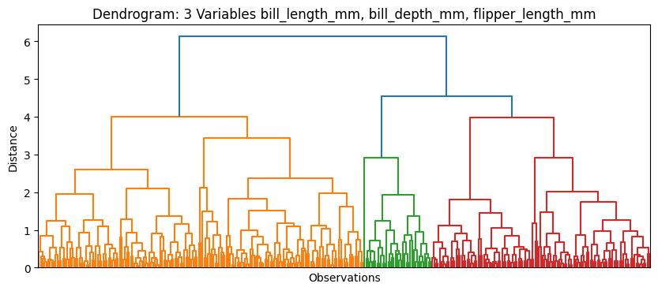

| col_0 species | 1 | 2 | 3 | 4 | 5 | 6 | 7 | 8 | 9 |
| --- | --- | --- | --- | --- | --- | --- | --- | --- | --- |
| Adelie | 44 | 43 | 15 | 44 | 0 | 0 | 0 | 0 | 0 |
| Chinstrap | 0 | 0 | 0 | 31 | 36 | 1 | 0 | 0 | 0 |
| Gentoo | 0 | 0 | 0 | 0 | 0 | 0 | 54 | 4 | 61 |

```python
np.random.seed(1)

features3 = ["bill_length_mm", "bill_depth_mm", "flipper_length_mm"]

X_scaled = StandardScaler().fit_transform(df[features3])

# Hierarchical clustering
Z = linkage(X_scaled, method="complete", metric="euclidean")

plt.figure(figsize=(10, 4))
dendrogram(Z, no_labels=True, )
plt.title(f"Dendrogram: 3 Variables {', '.join(features3)}")
plt.xlabel("Observations")
plt.ylabel("Distance")
plt.show()

# same cut style as your 4-variable code
labels = fcluster(Z, t=9, criterion="maxclust")

# Separation table
h_all3 = pd.crosstab(df["species"], labels)
h_all3
```

The grouping with three variables has excellent classification of species, particularly for Gentoo, but it is inferior to the grouping with four numerical variables since the Adelie and Chinstrap species still share a common cluster. Conversely, the grouping with four variables yields much better clustering, where there are very few instances outside of the main clusters for each species.

```python
def H(counts):
    counts = np.asarray(counts, dtype=float)
    total = counts.sum()
    if total == 0:
        return 0.0
    p = counts[counts > 0] / total
    return -np.sum(p * np.log(p))

def score_table(h):
    n = h.to_numpy().sum()
    Hy = H(h.sum(axis=1).to_numpy())
    Hy_given_B = 0.0
    for col in h.columns:
        col_counts = h[col].to_numpy()
        nb = col_counts.sum()
        if nb > 0:
            Hy_given_B += (nb / n) * H(col_counts)

    separation_score = 1 - (Hy_given_B / Hy) if Hy > 0 else 0.0
    purity = h.max(axis=0).sum() / n
    return separation_score, purity

tables_named = {
    "bill_length": h1,
    "flipper_length": h2,
    "bill_depth": h3,
    "body_mass": h4,
    "all3_bill_length_bill_depth_flipper": h_all3,
    "all4_numeric": h_all4,
    "island": h_island,
    "all4_plus_island": h_all4_island
}

rows = []
for name, h in tables_named.items():
    sep, pur = score_table(h)
    rows.append({
        "model": name,
        "separation_score": sep,
        "purity": pur
    })

results_df = pd.DataFrame(rows).sort_values("separation_score", ascending=False).reset_index(drop=True)
results_df.round(4)
```

|  | model | separation_score | purity |
| --- | --- | --- | --- |
| 0 | all4_numeric | 0.9253 | 0.9790 |
| 1 | all4_plus_island | 0.8871 | 0.9580 |
| 2 | all3_bill_length_bill_depth_flipper | 0.8551 | 0.9069 |
| 3 | flipper_length | 0.5308 | 0.7838 |
| 4 | island | 0.4880 | 0.7027 |
| 5 | bill_depth | 0.4531 | 0.7387 |
| 6 | body_mass | 0.4291 | 0.7057 |
| 7 | bill_length | 0.4223 | 0.6637 |

The separation score results provide additional support for the conclusions obtained from the clustering and entropy analyses. When the model using all four numerical variables was compared with the others, it showed the highest separation score and purity. For that reason, the four numerical variables were selected as the baseline model. Adding the variable island did not improve the separation score, even though it was still useful for prediction in a supervised model.

## Interacions

While the exact form of the interaction may be unknown, since there are many possible types of interactions between the variables, ranging from addition and multiplication to sine, cosine, and others, the most common convention for expressing the interaction between variables is by multiplying them. Therefore, multiplication was used here as an operational definition of the interaction. It is worth mentioning that the true form of interaction may not necessarily be multiplicative, but it is a plausible assumption.

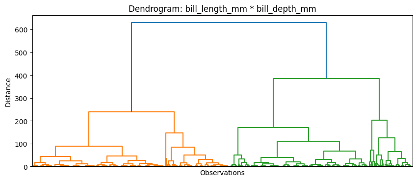

```
Contingency Table: bill_length_mm * bill_depth_mm
col_0       1   2   3  4   5
species
Adelie     60  32  52  0   2
Chinstrap   5   0  29  5  29
Gentoo     51  25  41  0   2
```

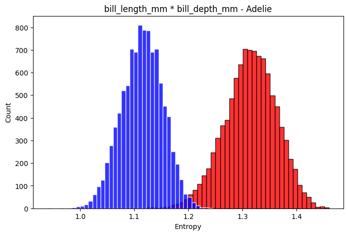

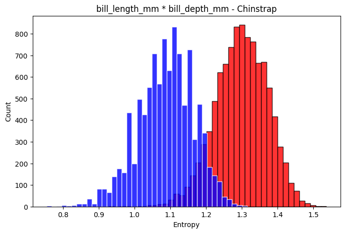

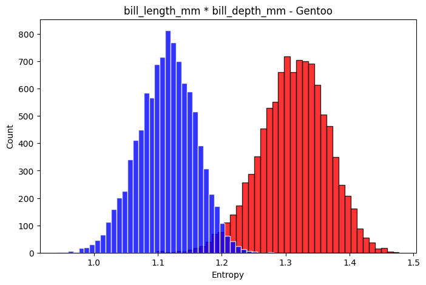

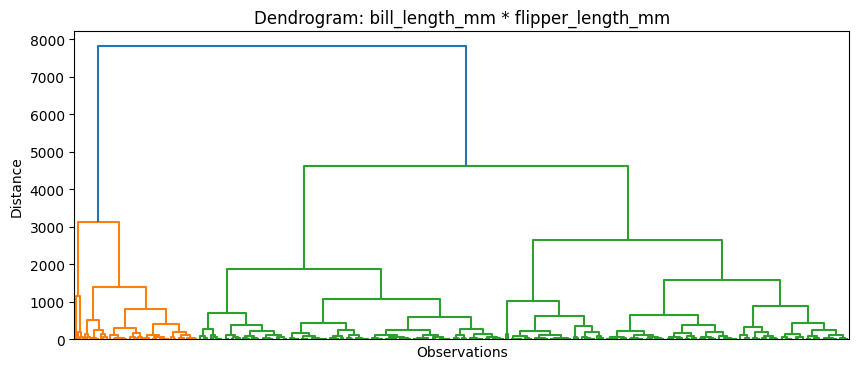

```
Contingency Table: bill_length_mm * flipper_length_mm
col_0      1   2   3   4   5   6   7
species
Adelie     0   0   5   0  43  57  41
Chinstrap  0   7  20  34   0   0   7
Gentoo     4  42  14  59   0   0   0
```

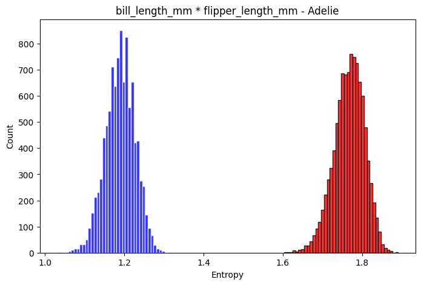

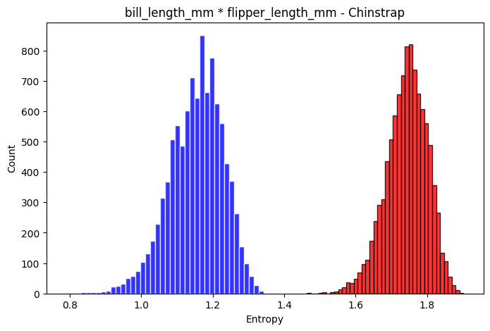

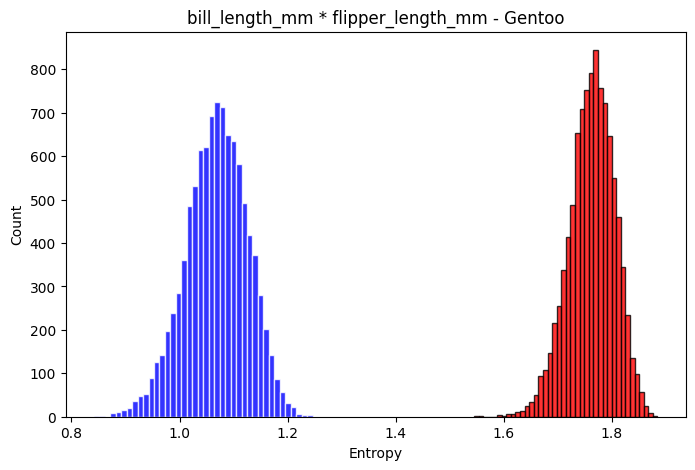

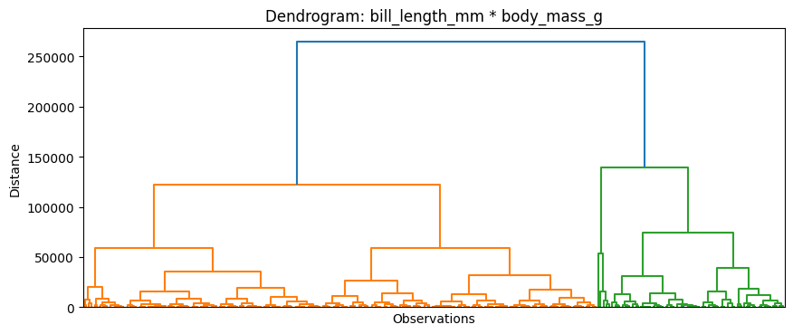

```
Contingency Table: bill_length_mm * body_mass_g
col_0        1   2  3   4
species
Adelie     103  43  0   0
Chinstrap   10  52  0   6
Gentoo       0  36  6  77
```

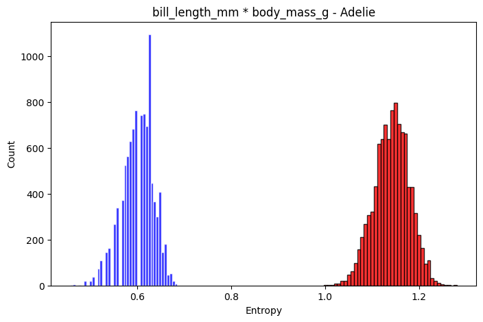

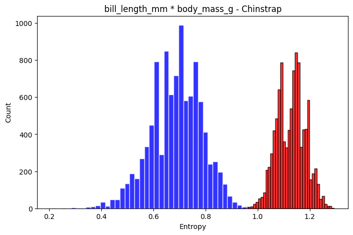

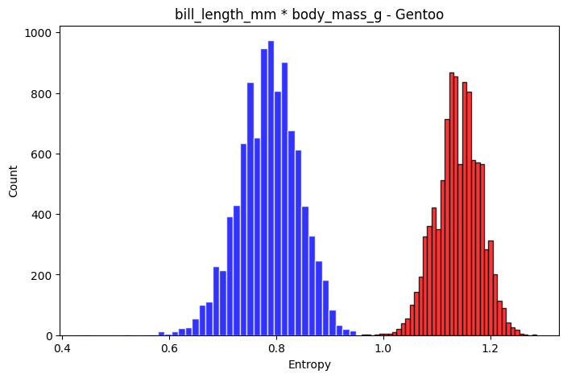

[12 more figures not shown]

```python
def make_h_table(X, title, criterion="maxclust", t=4):
    Z = linkage(X, method="complete", metric="euclidean")

    plt.figure(figsize=(10, 4))
    dendrogram(Z, no_labels=True)
    plt.title(f"Dendrogram: {title}")
    plt.xlabel("Observations")
    plt.ylabel("Distance")
    plt.show()

    labels = fcluster(Z, t=t, criterion=criterion)
    h = pd.crosstab(df["species"], labels)

    print(f"Contingency Table: {title}")
    print(h)
    return h

def plot_entropy_from_h(h, title):
    p_null = (h.sum(axis=0) / h.values.sum()).to_numpy()

    for sp in h.index:
        row = h.loc[sp].to_numpy()
        n_sp = int(row.sum())
        p_sp = row / n_sp

        ent_null = sim_entropy(n_sp, p_null)
        ent_sp = sim_entropy(n_sp, p_sp)

        plt.figure(figsize=(8, 5))
        plt.hist(ent_null, bins=40, edgecolor="black", alpha=0.8, color="red")
        plt.hist(ent_sp, bins=40, edgecolor="white", alpha=0.8, color="blue")
        plt.xlabel("Entropy")
        plt.ylabel("Count")
        plt.title(f"{title} - {sp}")
        plt.show()

X = (df["bill_length_mm"] * df["bill_depth_mm"]).to_numpy().reshape(-1, 1)
h_bl_bd = make_h_table(X, "bill_length_mm * bill_depth_mm", criterion="distance", t=200)
plot_entropy_from_h(h_bl_bd, "bill_length_mm * bill_depth_mm")

X = (df["bill_length_mm"] * df["flipper_length_mm"]).to_numpy().reshape(-1, 1)
h_bl_fl = make_h_table(X, "bill_length_mm * flipper_length_mm", criterion="distance", t=1500)
plot_entropy_from_h(h_bl_fl, "bill_length_mm * flipper_length_mm")

X = (df["bill_length_mm"] * df["body_mass_g"]).to_numpy().reshape(-1, 1)
h_bl_bm = make_h_table(X, "bill_length_mm * body_mass_g", criterion="maxclust", t=4)
plot_entropy_from_h(h_bl_bm, "bill_length_mm * body_mass_g")

X = (df["bill_depth_mm"] * df["flipper_length_mm"]).to_numpy().reshape(-1, 1)
h_bd_fl = make_h_table(X, "bill_depth_mm * flipper_length_mm", criterion="distance", t=400)
plot_entropy_from_h(h_bd_fl, "bill_depth_mm * flipper_length_mm")

X = (df["bill_depth_mm"] * df["body_mass_g"]).to_numpy().reshape(-1, 1)
h_bd_bm = make_h_table(X, "bill_depth_mm * body_mass_g", criterion="distance", t=10000)
plot_entropy_from_h(h_bd_bm, "bill_depth_mm * body_mass_g")

X = (df["flipper_length_mm"] * df["body_mass_g"]).to_numpy().reshape(-1, 1)
h_fl_bm = make_h_table(X, "flipper_length_mm * body_mass_g", criterion="distance", t=200000)
plot_entropy_from_h(h_fl_bm, "flipper_length_mm * body_mass_g")
```

From the interaction plots, the combinations bill length × body mass, bill length × flipper length, and flipper length × body mass all show useful species structure. In these cases, the observed entropy distributions are clearly lower than the null distributions, which suggests that these interactions are not behaving randomly. The contingency tables also show that species tend to concentrate in different clusters instead of being evenly mixed. So overall, these interactions seem to carry useful information for separating penguin species.

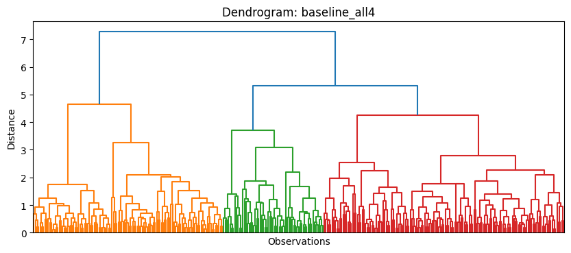

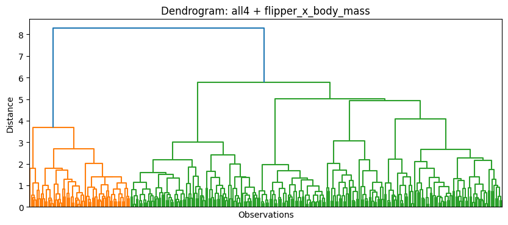

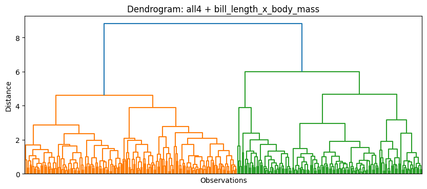

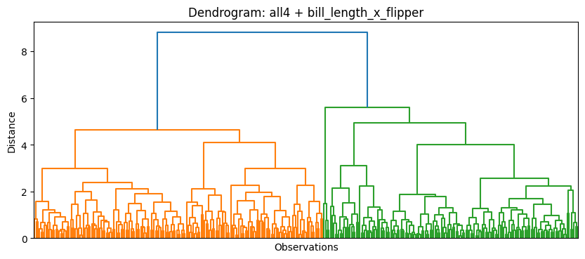

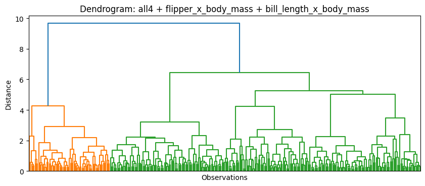

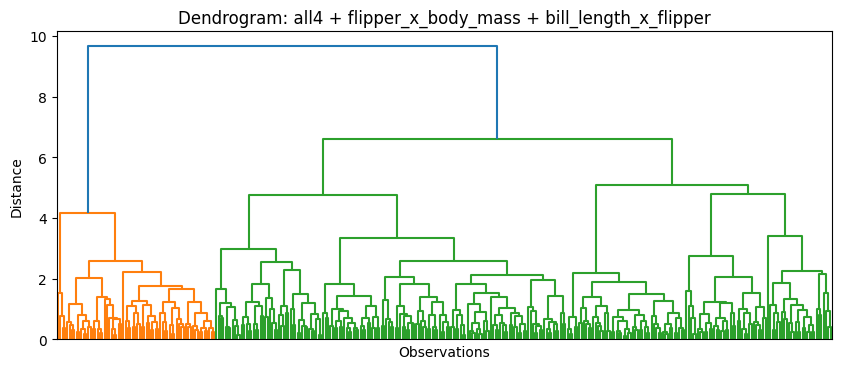

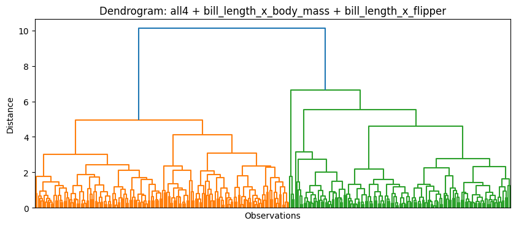

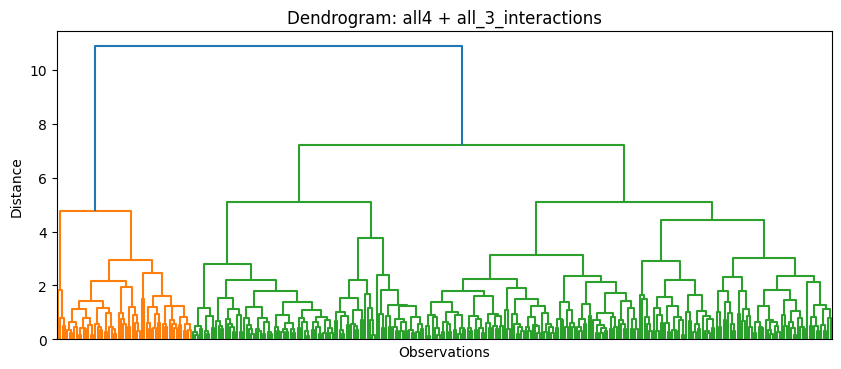

|  | model | k | separation_score | purity |
| --- | --- | --- | --- | --- |
| 0 | all4 + all_3_interactions | 9 | 0.9457 | 0.982 |
| 1 | all4 + bill_length_x_flipper | 10 | 0.9328 | 0.982 |
| 2 | all4 + bill_length_x_body_mass | 9 | 0.9273 | 0.982 |
| 3 | baseline_all4 | 9 | 0.9253 | 0.979 |
| 4 | all4 + flipper_x_body_mass + bill_length_x_body_mass | 10 | 0.9204 | 0.979 |
| 5 | all4 + flipper_x_body_mass + bill_length_x_flipper | 9 | 0.9191 | 0.979 |
| 6 | all4 + flipper_x_body_mass | 9 | 0.9159 | 0.976 |
| 7 | all4 + bill_length_x_body_mass + bill_length_x_flipper | 9 | 0.9109 | 0.973 |

```python
interaction_pairs = {
    "flipper_x_body_mass": ("flipper_length_mm", "body_mass_g"),
    "bill_length_x_body_mass": ("bill_length_mm", "body_mass_g"),
    "bill_length_x_flipper": ("bill_length_mm", "flipper_length_mm"),
}
for new_col, (a, b) in interaction_pairs.items():
    df[new_col] = df[a] * df[b]

base_features = ["bill_length_mm", "bill_depth_mm", "flipper_length_mm", "body_mass_g"]
inter_cols = list(interaction_pairs.keys())

models = {"baseline_all4": base_features}
for r in range(1, len(inter_cols) + 1):
    for combo in combinations(inter_cols, r):
        if r == len(inter_cols):
            name = "all4 + all_3_interactions"
        else:
            name = "all4 + " + " + ".join(combo)
        models[name] = base_features + list(combo)


Z_map = {}
for name, feats in models.items():
    X = StandardScaler().fit_transform(df[feats])
    Z = linkage(X, method="complete", metric="euclidean")
    Z_map[name] = Z

    plt.figure(figsize=(10, 4))
    dendrogram(Z, no_labels=True)
    plt.title(f"Dendrogram: {name}")
    plt.xlabel("Observations")
    plt.ylabel("Distance")
    plt.show()

k_choice = {
    "baseline_all4": 9,
    "all4 + flipper_x_body_mass": 9,
    "all4 + bill_length_x_body_mass": 9,
    "all4 + bill_length_x_flipper": 10,
    "all4 + flipper_x_body_mass + bill_length_x_body_mass": 10,
    "all4 + flipper_x_body_mass + bill_length_x_flipper": 9,
    "all4 + bill_length_x_body_mass + bill_length_x_flipper": 9,
    "all4 + all_3_interactions": 9,
}

rows = []
h_tables = {}

for name in models:
    k = k_choice[name]
    labels = fcluster(Z_map[name], t=k, criterion="maxclust")
    h = pd.crosstab(df["species"], labels)
    h_tables[name] = h

    sep, pur = score_table(h)
    rows.append({
        "model": name,
        "k": k,
        "separation_score": sep,
        "purity": pur
    })

results = pd.DataFrame(rows).sort_values("separation_score", ascending=False).reset_index(drop=True)
display(results.round(4))
```

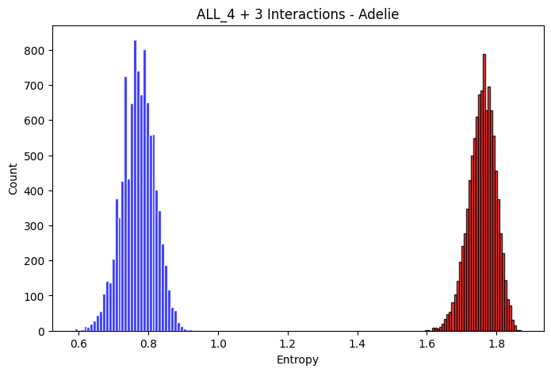

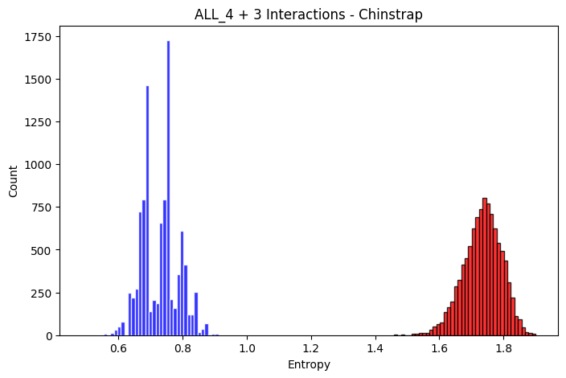

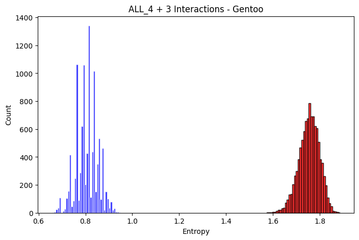

```python
plot_entropy_from_h(h_all4_plus_int3, "ALL_4 + 3 Interactions")
```

After looking at how effective the models with just the numerical features were, the next step was to analyze more complex models including interaction terms. Given the results from the separation score, the best interaction-based model was the one that involved all four numerical features together with all three interaction terms. This particular model achieved the highest separation score, 0.9457, and the highest purity, 0.982, thus it can be concluded that it provided the strongest separation among the interaction-based models analyzed. Entropy charts also confirmed this conclusion, because in the case of Adelie, Chinstrap, and Gentoo birds, the observed entropies turned out to be much smaller than the corresponding null entropy distributions.

# Prediction

The earlier variable separation analysis addressed the question of which variables or combinations of variables best separated the species. Prediction, however, serves a slightly different purpose. When predicting species, it is important to keep not only the variables that provide the strongest overall separation, but also variables that still carry useful species information, even if they do not separate all three species equally well. This is because the separation analysis measures the overall structure of the data, while a predictive model uses variables as clues for making the best possible classification. In other words, a variable does not have to be the strongest overall separator to still improve prediction. Therefore, my final predictive model includes bill length, bill depth, flipper length, body mass, flipper length × body mass, bill length × body mass, bill length × flipper length, and island.

```python
df["flipper_x_body_mass"] = df["flipper_length_mm"] * df["body_mass_g"]
df["bill_length_x_body_mass"] = df["bill_length_mm"] * df["body_mass_g"]
df["bill_length_x_flipper"] = df["bill_length_mm"] * df["flipper_length_mm"]


num_feats = [
    "bill_length_mm", "bill_depth_mm", "flipper_length_mm", "body_mass_g",
    "flipper_x_body_mass", "bill_length_x_body_mass", "bill_length_x_flipper"
]


X_num = df[num_feats].copy()
X_island = pd.get_dummies(df["island"], prefix="island", drop_first=False)
X = pd.concat([X_num, X_island], axis=1)

y = df["species"]

cv = StratifiedKFold(n_splits=5, shuffle=True, random_state=1)

acc_scores = []
f1_scores = []
bal_scores = []

for fold, (train_idx, test_idx) in enumerate(cv.split(X, y), 1):
    X_train, X_test = X.iloc[train_idx], X.iloc[test_idx]
    y_train, y_test = y.iloc[train_idx], y.iloc[test_idx]

    rf = RandomForestClassifier(
        n_estimators=500,
        random_state=1,
        class_weight="balanced"
    )
    rf.fit(X_train, y_train)

    y_pred = rf.predict(X_test)

    acc = accuracy_score(y_test, y_pred)
    f1m = f1_score(y_test, y_pred, average="macro")
    bal = balanced_accuracy_score(y_test, y_pred)

    acc_scores.append(acc)
    f1_scores.append(f1m)
    bal_scores.append(bal)

    print(f"Fold {fold}: acc={acc:.4f}, f1_macro={f1m:.4f}, bal_acc={bal:.4f}")

print("\nCV summary:")
print(f"Accuracy:      {np.mean(acc_scores):.4f} ± {np.std(acc_scores):.4f}")
print(f"F1 macro:      {np.mean(f1_scores):.4f} ± {np.std(f1_scores):.4f}")
print(f"Balanced Acc.: {np.mean(bal_scores):.4f} ± {np.std(bal_scores):.4f}")
```

```
Fold 1: acc=0.9851, f1_macro=0.9829, bal_acc=0.9889
Fold 2: acc=1.0000, f1_macro=1.0000, bal_acc=1.0000
Fold 3: acc=0.9851, f1_macro=0.9820, bal_acc=0.9762
Fold 4: acc=0.9697, f1_macro=0.9611, bal_acc=0.9487
Fold 5: acc=1.0000, f1_macro=1.0000, bal_acc=1.0000

CV summary:
Accuracy:      0.9880 ± 0.0113
F1 macro:      0.9852 ± 0.0144
Balanced Acc.: 0.9828 ± 0.0192
```

The results obtained from the prediction model were exceptionally good for 5-fold cross-validation. The average accuracy achieved by the model was found to be 0.9880, whereas the average macro F1 was recorded at 0.9852 and the average balanced accuracy was observed at 0.9828. From these figures, it can be concluded that the model is able to predict the penguin species with very high accuracy, and this is true for all the three species of penguins.

# Conclusion

The primary objective of this study was to figure out which factors best differentiate the types of penguins. As a result, the best single variable separators were found to be those related to flipper length, bill depth, body mass, and bill length, although they separated the penguins differently. Flipper length is considered one of the best single variable separators since it can easily differentiate between the Gentoo and Adelie species; however, Chinstrap still overlaps in the medium range with both of them. Bill depth and body mass are two other effective separators, mostly due to the fact that they can differentiate the Gentoo penguin from others. Bill length is also a significant variable that works better at the lower part of the scale since Adelie penguins can be distinguished from Chinstrap and Gentoo penguins there. The last variable that can also help separate species is island, since Chinstrap and Gentoo are mostly connected to one island, while Adelie is spread across all three islands.

When variables were used in combination, the species separation became much clearer compared to using individual variables alone. According to the pair plots, the combinations of bill depth with flipper length, bill depth with body mass, and flipper length with body mass were helpful for distinguishing Gentoo from both Adelie and Chinstrap, whereas the combinations involving bill length were more useful for separating all three species together. The multivariable clustering also showed that the clearest overall structure was obtained when all four numerical variables were used at the same time, because this gave a highly separated distribution with only a small amount of overlap between species, although some interaction variables also helped improve the separation. However, most of the biological structure had already been captured by the four numerical variables alone.

In general, the important variables, that proved to be significant in differentiation, are the following: the length of flipper, body mass, bill depth, and bill length. As for their significance, each of them contributes differently to the classification process; some of them are better for distinguishing Gentoo, whereas others can be used when distinguishing Adelie. It should be noted that among all three species of penguins, Chinstrap is the most difficult one to identify by its measurements since it overlaps significantly with other species concerning a number of variables. In general, this result proves that data are not random but have certain structure. For instance, Gentoo differs from other species the most, while in some cases, Adelie can be distinguished from Chinstrap. However, despite the fact that this project focused mainly on successful prediction, much attention was paid to analysis of results.